# 7.1 Handling Missing Data

Missing data occurs commonly in many data analysis applications. One of the goals of pandas is to make working with missing data as painless as possible. For example, **all of the descriptive statistics on pandas objects exclude missing data by default**

- The way that missing data is represented in pandas objects is somewhat imperfect, but it is functional for a lot of users.
- For numeric data, pandas uses the floating-point value `NaN` (Not a Number) to represent missing data. We call this a **sentinel value** that can be easily detected:

```python
import pandas as pd
import numpy as np
```

```python
string_data = pd.Series(['aardvark', 'artichoke', np.nan, 'avocado'])
string_data
```

```
0     aardvark
1    artichoke
2          NaN
3      avocado
dtype: object
```

```python
string_data.isnull()
```

```
0    False
1    False
2     True
3    False
dtype: bool
```

- In pandas, we’ve adopted a convention used in the R programming language by referring to missing data as `NA`, **which stands for not available.**
- In statistics applications, NA data may either be data that does not exist or that exists but was not observed
- The built-in Python `None` value is also treated as `NA` in object arrays:

```python
string_data[0] = None
string_data.isnull()
```

```
0     True
1    False
2     True
3    False
dtype: bool
```

#### See Table 7-1 for a list of some functions related to missing data handling.

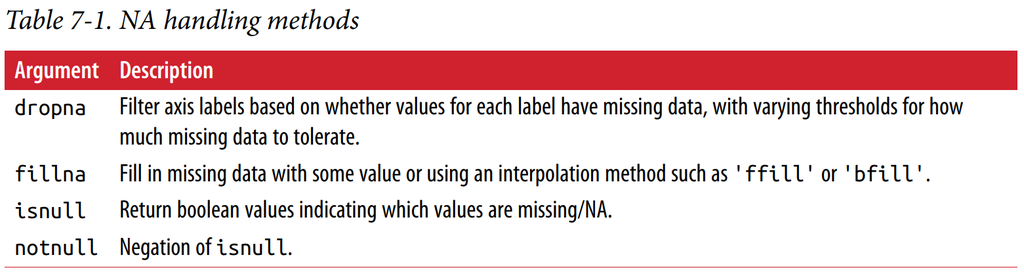

### 1. Filtering Out Missing Data

There are a few ways to filter out missing data.

- While you always have the option to do it by hand using `pandas.isnull` and boolean indexing, the `dropna` can be helpful

```python
from numpy import nan as NA
data = pd.Series([1, NA, 3.5, NA, 7])
data.dropna()
```

```
0    1.0
2    3.5
4    7.0
dtype: float64
```

#### This is equivalent to:

```python
data[data.notnull()]
```

```
0    1.0
2    3.5
4    7.0
dtype: float64
```

#### With DataFrame objects, things are a bit more complex.

- `dropna` by default drops any row containing a missing value:

```python
data = pd.DataFrame([[1., 6.5, 3.], [1., NA, NA],[NA, NA, NA], [NA, 6.5, 3.]])
data
```

|  | 0 | 1 | 2 |
| --- | --- | --- | --- |
| 0 | 1.0 | 6.5 | 3.0 |
| 1 | 1.0 | NaN | NaN |
| 2 | NaN | NaN | NaN |
| 3 | NaN | 6.5 | 3.0 |

```python
cleaned = data.dropna()
cleaned
```

|  | 0 | 1 | 2 |
| --- | --- | --- | --- |
| 0 | 1.0 | 6.5 | 3.0 |

#### Passing `how='all'` will only drop rows that are all NA:

```python
data.dropna(how='all')
```

|  | 0 | 1 | 2 |
| --- | --- | --- | --- |
| 0 | 1.0 | 6.5 | 3.0 |
| 1 | 1.0 | NaN | NaN |
| 3 | NaN | 6.5 | 3.0 |

#### To drop columns in the same way, pass `axis=1:`

```python
data[4] = NA
data
```

|  | 0 | 1 | 2 | 4 |
| --- | --- | --- | --- | --- |
| 0 | 1.0 | 6.5 | 3.0 | NaN |
| 1 | 1.0 | NaN | NaN | NaN |
| 2 | NaN | NaN | NaN | NaN |
| 3 | NaN | 6.5 | 3.0 | NaN |

```python
data.dropna(axis=1, how='all')
```

|  | 0 | 1 | 2 |
| --- | --- | --- | --- |
| 0 | 1.0 | 6.5 | 3.0 |
| 1 | 1.0 | NaN | NaN |
| 2 | NaN | NaN | NaN |
| 3 | NaN | 6.5 | 3.0 |

A related way to filter out DataFrame rows tends to concern time series data.

- Suppose you want to **keep only rows containing a certain number of observations.** You can indicate this with the `thresh` argument:

```python
df = pd.DataFrame(np.random.randn(7, 3))
df.iloc[:4, 1] = NA
df.iloc[:2, 2] = NA
df
```

|  | 0 | 1 | 2 |
| --- | --- | --- | --- |
| 0 | -0.952921 | NaN | NaN |
| 1 | 0.276267 | NaN | NaN |
| 2 | 0.760786 | NaN | -0.808315 |
| 3 | -0.713527 | NaN | 0.416105 |
| 4 | -0.324210 | 1.736784 | 1.096385 |
| 5 | -0.256604 | 0.308013 | 1.808138 |
| 6 | -0.199655 | 0.575004 | -0.107670 |

```python
df.dropna()
```

|  | 0 | 1 | 2 |
| --- | --- | --- | --- |
| 4 | -0.324210 | 1.736784 | 1.096385 |
| 5 | -0.256604 | 0.308013 | 1.808138 |
| 6 | -0.199655 | 0.575004 | -0.107670 |

```python
df.dropna(thresh=2)
```

|  | 0 | 1 | 2 |
| --- | --- | --- | --- |
| 2 | 0.760786 | NaN | -0.808315 |
| 3 | -0.713527 | NaN | 0.416105 |
| 4 | -0.324210 | 1.736784 | 1.096385 |
| 5 | -0.256604 | 0.308013 | 1.808138 |
| 6 | -0.199655 | 0.575004 | -0.107670 |

### 2. Filling In Missing Data

For most purposes, the `fillna` method is the workhorse function to use. Calling fillna with a constant replaces missing values with that value:

```python
df.fillna(0)
```

|  | 0 | 1 | 2 |
| --- | --- | --- | --- |
| 0 | -0.952921 | 0.000000 | 0.000000 |
| 1 | 0.276267 | 0.000000 | 0.000000 |
| 2 | 0.760786 | 0.000000 | -0.808315 |
| 3 | -0.713527 | 0.000000 | 0.416105 |
| 4 | -0.324210 | 1.736784 | 1.096385 |
| 5 | -0.256604 | 0.308013 | 1.808138 |
| 6 | -0.199655 | 0.575004 | -0.107670 |

Calling `fillna` with a dict, you can **use a different fill value for each column:**

```python
df.fillna({1: 0.5, 2: 0})
```

|  | 0 | 1 | 2 |
| --- | --- | --- | --- |
| 0 | -0.952921 | 0.500000 | 0.000000 |
| 1 | 0.276267 | 0.500000 | 0.000000 |
| 2 | 0.760786 | 0.500000 | -0.808315 |
| 3 | -0.713527 | 0.500000 | 0.416105 |
| 4 | -0.324210 | 1.736784 | 1.096385 |
| 5 | -0.256604 | 0.308013 | 1.808138 |
| 6 | -0.199655 | 0.575004 | -0.107670 |

The same interpolation methods available for reindexing can be used with `fillna`:

```python
df = pd.DataFrame(np.random.randn(6, 3))
df.iloc[2:, 1] = NA
df.iloc[4:, 2] = NA
df
```

|  | 0 | 1 | 2 |
| --- | --- | --- | --- |
| 0 | 0.260642 | 0.017750 | 1.036211 |
| 1 | -0.717592 | -0.472621 | 0.602104 |
| 2 | 0.074856 | NaN | -0.381256 |
| 3 | 1.286412 | NaN | -1.157350 |
| 4 | -0.686835 | NaN | NaN |
| 5 | -0.213994 | NaN | NaN |

```python
df.fillna(method='ffill')
```

|  | 0 | 1 | 2 |
| --- | --- | --- | --- |
| 0 | 0.260642 | 0.017750 | 1.036211 |
| 1 | -0.717592 | -0.472621 | 0.602104 |
| 2 | 0.074856 | -0.472621 | -0.381256 |
| 3 | 1.286412 | -0.472621 | -1.157350 |
| 4 | -0.686835 | -0.472621 | -1.157350 |
| 5 | -0.213994 | -0.472621 | -1.157350 |

```python
df.fillna(method='ffill', limit=2)
```

|  | 0 | 1 | 2 |
| --- | --- | --- | --- |
| 0 | 0.260642 | 0.017750 | 1.036211 |
| 1 | -0.717592 | -0.472621 | 0.602104 |
| 2 | 0.074856 | -0.472621 | -0.381256 |
| 3 | 1.286412 | -0.472621 | -1.157350 |
| 4 | -0.686835 | NaN | -1.157350 |
| 5 | -0.213994 | NaN | -1.157350 |

#### With `fillna` you can do lots of other things with a little creativity.

- For example, you might pass the mean or median value of a Series:

```python
data = pd.Series([1., NA, 3.5, NA, 7])
data.fillna(data.mean())
```

```
0    1.000000
1    3.833333
2    3.500000
3    3.833333
4    7.000000
dtype: float64
```

#### See Table 7-2 for a reference on `fillna`.

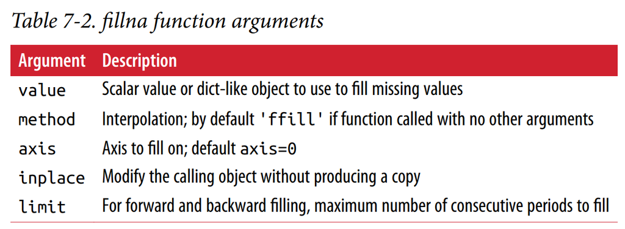